# Python Analysis - Homework

# 1 Analysis tasks

In the following analysis tasks, we are going to use a data set on incidences of forest fires in the north east of Portugal. You can find a description of the dataset [here](https://archive.ics.uci.edu/ml/datasets/forest+fires).

## 1.1 Read data

- Import the `pandas` and `numpy` packages.

```python
import pandas as pd
import numpy as np
```

- Now read the file `forestfires.csv` and look at the first few rows.

```python
fires = pd.read_csv("forestfires.csv")
fires.head()
```

```
##    X  Y month  day  temp  wind  rain  area
## 0  7  5   mar  fri   8.2   6.7   0.0   NaN
## 1  7  4   oct  tue  18.0   0.9   0.0   NaN
## 2  7  4   oct  sat  14.6   1.3   0.0   NaN
## 3  8  6   mar  fri   8.3   4.0   0.2   NaN
## 4  8  6   mar  sun  11.4   1.8   0.0   NaN
```

- Have a look at the methods available on a `pandas` dataframe.
  - We’ve already seen `describe()`, so run that on the dataframe you loaded above.
  - Run another method providing general information on the stored data.

```python
fires.describe(include = "all")
# info() provides general summary information on the stored data
```

```
##                  X           Y month  ...        wind        rain         area
## count   517.000000  517.000000   517  ...  516.000000  517.000000   379.000000
## unique         NaN         NaN    12  ...         NaN         NaN          NaN
## top            NaN         NaN   aug  ...         NaN         NaN          NaN
## freq           NaN         NaN   184  ...         NaN         NaN          NaN
## mean      4.669246    4.299807   NaN  ...    4.019380    0.021663    17.525198
## std       2.313778    1.229900   NaN  ...    1.792934    0.295959    73.818628
## min       1.000000    2.000000   NaN  ...    0.400000    0.000000     0.000000
## 25%       3.000000    4.000000   NaN  ...    2.700000    0.000000     0.000000
## 50%       4.000000    4.000000   NaN  ...    4.000000    0.000000     2.570000
## 75%       7.000000    5.000000   NaN  ...    4.900000    0.000000     9.985000
## max       9.000000    9.000000   NaN  ...    9.400000    6.400000  1090.840000
##
## [11 rows x 8 columns]
```

```python
fires.info(verbose = True, null_counts =True)
```

```
## <class 'pandas.core.frame.DataFrame'>
## RangeIndex: 517 entries, 0 to 516
## Data columns (total 8 columns):
## X        517 non-null int64
## Y        517 non-null int64
## month    517 non-null object
## day      517 non-null object
## temp     515 non-null float64
## wind     516 non-null float64
## rain     517 non-null float64
## area     379 non-null float64
## dtypes: float64(4), int64(2), object(2)
## memory usage: 32.4+ KB
```

## 1.2 Missing data

- Which variables having missing data in this data frame?
  - Replace all the missing values in `area` with 0
  - Remove the rows that have missing values in other columns

```python
fires.isnull().sum()
# area, temp and wind all have missing data
```

```
## X          0
## Y          0
## month      0
## day        0
## temp       2
## wind       1
## rain       0
## area     138
## dtype: int64
```

```python
fires = fires.fillna({"area": 0})

fires.dropna(inplace = True)
```

## 1.3 Using the “Verbs”

### 1.3.1 Select

- Change your data frame so that columns `X` and `Y` are dropped.

```python
#fires = fires[['month', 'day', 'temp', 'wind', 'rain', 'area']]
# or
fires = fires.drop(columns = ["X", "Y"], axis = 1)
fires.head()
```

```
##   month  day  temp  wind  rain  area
## 0   mar  fri   8.2   6.7   0.0   0.0
## 1   oct  tue  18.0   0.9   0.0   0.0
## 2   oct  sat  14.6   1.3   0.0   0.0
## 3   mar  fri   8.3   4.0   0.2   0.0
## 4   mar  sun  11.4   1.8   0.0   0.0
```

### 1.3.2 Arrange

- Change your data frame so that it is arranged by `area`, so that the highest `area` fires are first

```python
fires = fires.sort_values('area', ascending = False)
```

### 1.3.3 Filter

- Change your data frame so that it contains no rows where `area` is zero.

```python
fires = fires[fires['area'] != 0]
```

### 1.3.4 Mutate

- Create a new column `is_rain`, which is equal to `True` whenever `rain` is greater than zero and `False` otherwise.

```python
fires['is_rain'] = fires['rain'] > 0
```

### 1.3.5 Group by and summarise

- Find the average `area` of fire:
  - In each `month` of the year
  - In each `day` of the week
  - When there is rain, and when there isn’t rain

```python
fires.groupby('month')['area'].mean()
```

```
## month
## apr    20.005000
## aug    23.441939
## dec    13.330000
## feb    12.550000
## jul    25.546111
## jun    12.412500
## mar    12.382105
## may    38.480000
## oct    19.914000
## sep    31.815773
## Name: area, dtype: float64
```

```python
fires.groupby('day')['area'].mean()
```

```
## day
## fri    10.400930
## mon    18.116154
## sat    51.068095
## sun    20.424043
## thu    32.164516
## tue    22.438611
## wed    18.642581
## Name: area, dtype: float64
```

```python
fires.groupby('is_rain')['area'].mean()
```

```
## is_rain
## False    24.825393
## True      6.495000
## Name: area, dtype: float64
```

## 1.4 Plotting

- Use `matplotlib` to create a histogram of `area`
- Use `seaborn` to create a histogram of `area`
- Use seaborn to create a scatter plot of `temp` vs. `area`

```python
%matplotlib inline
```

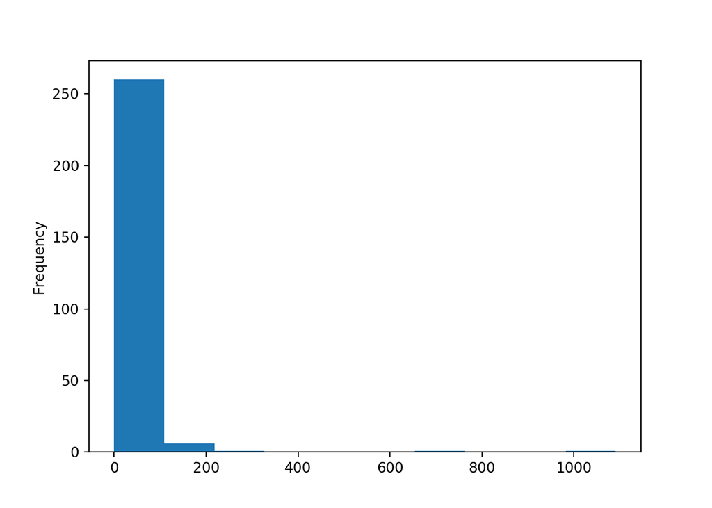

```python
import matplotlib as plt
import seaborn as sns

fires["area"].plot(kind="hist")
```

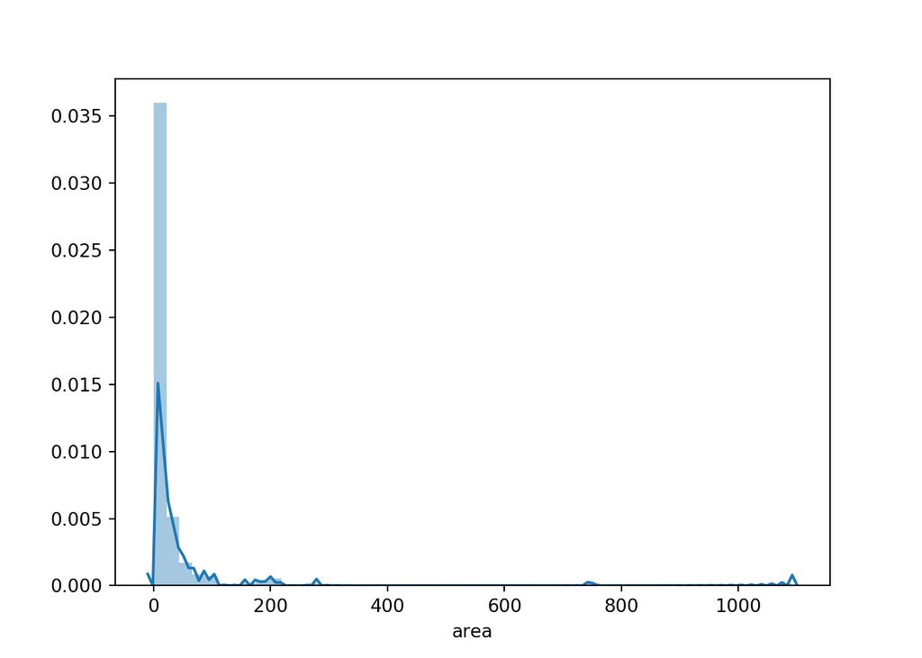

```python
sns.distplot(fires['area'])
```

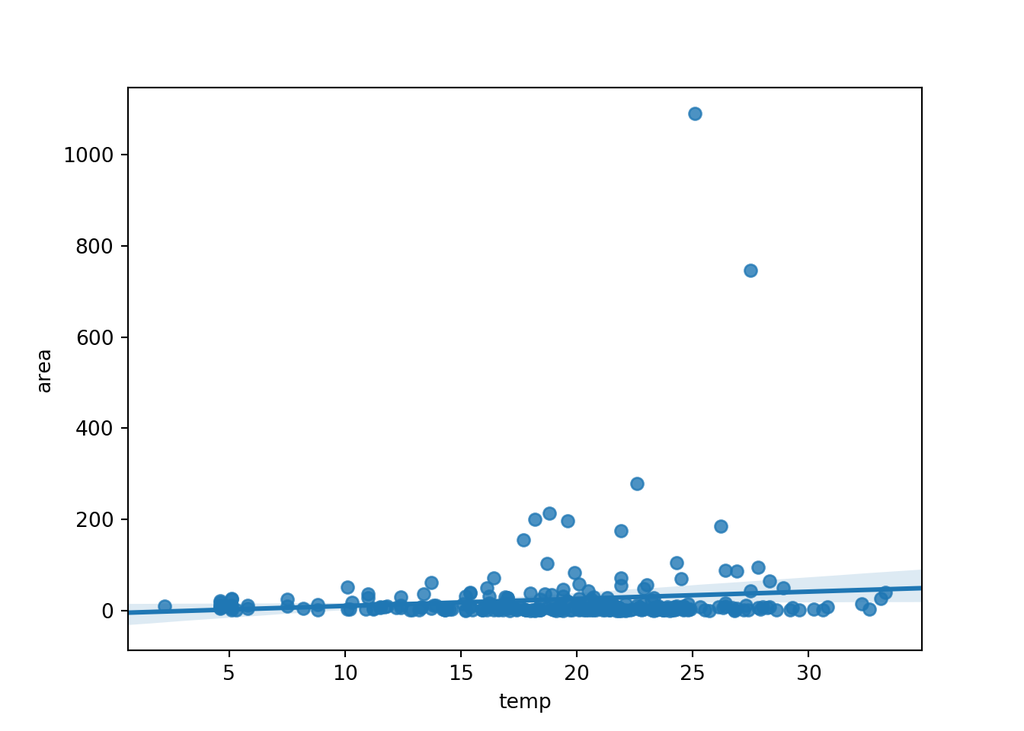

```python
sns.regplot(x = 'temp', y = 'area', data = fires)
```